# PEC4 sobre Asociación

UOC - Master BI - Business Analytics (Nombre Estudiante)

Mayo del 2018

# 1 Base teórica

Para realizar la práctica se recomienda la lectura del punto 3.4 del material didáctico. Este punto se centra en la búsqueda de asociaciones las cuales en nuestro caso se darán entre las características de la población adulta de USA.

El algoritmo **apriori** fue diseñado para la búsqueda de asociaciones entre los productos que forman parte de la cesta de la compra en el supermercado, hipermercado o gran superficie. El objetivo era determinar qué productos eran causa de la compra de otros. Sin embargo, el algoritmo **apriori** puede generalizarse para la búsqueda de asociaciones entre cualquier conjunto de items.

En esta PEC el objetivo será buscar asociaciones y relaciones en un juego de datos sobre la población adulta de USA. Se han identificado una serie de características de la misma y se quiere averiguar si existen relaciones entre ellas.

Para ello utilizaremos el paquete **R** denominado **arules** del que podréis encontrar información extensa en el siguiente enlace https://cran.r-project.org/web/packages/arules/vignettes/arules.pdf

# 2 Descripción del problema

Vamos a analizar la relación entre características que definen la población adulta de USA según las siguientes características.

1. age
2. workclass
3. fnlwgt: final weight
4. education
5. education-num
6. marital-status
7. occuptaion
8. relationship
9. race
10. sex
11. capital-gain
12. capital-loss
13. hours-per-week
14. native-country
15. income

Podéis encontrar más información sobre el juego de datos en el siguiente enlace https://archive.ics.uci.edu/ml/datasets/adult

# 3 Cargar el juego de datos

Un juego de datos para poder ser usado por algoritmos de búsqueda de asociaciones debe tener una estructura de transacciones en la que cada fila represente una transacción, por ejemplo en una cesta de la compra diríamos que cada fila representa una compra.

En nuestro caso una transacción o fila del juego de datos representa un individuo de la población de USA.

La generación de reglas de asociación requiere que las características a estudiar sean categóricas y no continuas, por este motivo debemos prever un proceso de conversión de variables continuas en categóricas, para ello nos apoyaremos en la función **R** **cut()**.

```r
library(arules)
data("AdultUCI")

# Proceso de categorización de variables continuas
AdultC <- AdultUCI
AdultC$age <- cut(AdultUCI$age, c(15,25,30,35,45,55,65,100))
AdultC$workclass <- AdultUCI$workclass
AdultC$fnlwgt <- cut(AdultUCI$fnlwgt, c(12200,20000,50000,100000,500000,750000,1000000,1500000))
AdultC$education <- AdultUCI$education
AdultC$`education-num` <- cut(AdultUCI$`education-num`, c(1,5,10,15,20))
AdultC$`marital-status` <- AdultUCI$`marital-status`
AdultC$occupation <- AdultUCI$occupation
AdultC$relationship <- AdultUCI$relationship
AdultC$race <- AdultUCI$race
AdultC$sex <- AdultUCI$sex
AdultC$`capital-gain` <- cut(AdultUCI$`capital-gain`, c(0,15000,20000,30000,40000,50000,60000,80000,100000))
AdultC$`capital-loss` <- cut(AdultUCI$`capital-loss`, c(0,500,1000,2000,3000,4000,5000))
AdultC$`hours-per-week` <- cut(AdultUCI$`hours-per-week`, c(0,10,20,30,50,60,80,100))
AdultC$`native-country` <- AdultUCI$`native-country`
AdultC$income <- AdultUCI$income
```

# 4 Función arules()

En R el juego de datos debe estar en formato **transaction**. Si no lo está, deberemos usar comandos **R** para proceder a su conversión.  
Observamos que en el proceso de generación de reglas exigimos que un soporte y una confianza mínimas.

```r
# Convesión del juego de datos a formato transacción
Adult = as(AdultC, "transactions")

# Generacón de reglas con soporte y confianza mínimos
rules = apriori(Adult, parameter=list(support=0.01, confidence=0.7, maxlen=7))
```

```
## Apriori
##
## Parameter specification:
##  confidence minval smax arem  aval originalSupport maxtime support minlen
##         0.7    0.1    1 none FALSE            TRUE       5    0.01      1
##  maxlen target   ext
##       7  rules FALSE
##
## Algorithmic control:
##  filter tree heap memopt load sort verbose
##     0.1 TRUE TRUE  FALSE TRUE    2    TRUE
##
## Absolute minimum support count: 488
##
## set item appearances ...[0 item(s)] done [0.00s].
## set transactions ...[138 item(s), 48842 transaction(s)] done [0.02s].
## sorting and recoding items ... [76 item(s)] done [0.01s].
## creating transaction tree ... done [0.02s].
## checking subsets of size 1 2 3 4 5 6 7
```

```
##  done [0.50s].
## writing ... [170708 rule(s)] done [0.03s].
## creating S4 object  ... done [0.06s].
```

```r
# Listado de reglas obtenidas
rules
```

```
## set of 170708 rules
```

Es importante poder filtrar entre las reglas generadas, porque será tarea del analista identificar las más representativas. Mostramos a continuación formas distintas de filtrado de reglas.

```r
# Listamos las 3 reglas con mayor lift
inspect(head(sort(rules, by="lift"),3));
```

```
##     lhs                        rhs                        support confidence     lift
## [1] {education=Doctorate}   => {education-num=(15,20]} 0.01216166          1 82.22559
## [2] {education-num=(15,20]} => {education=Doctorate}   0.01216166          1 82.22559
## [3] {education=Doctorate,
##      race=White}            => {education-num=(15,20]} 0.01076942          1 82.22559
```

```r
# Visualizamos la calidad de las reglas generadas
head(quality(rules));
```

```
##      support confidence      lift
## 1 0.72798002  0.7279800  1.000000
## 2 0.81364399  0.8136440  1.000000
## 3 0.85504279  0.8550428  1.000000
## 4 0.89742435  0.8974243  1.000000
## 5 0.01042136  1.0000000 19.798135
## 6 0.01050326  0.9624765  2.100598
```

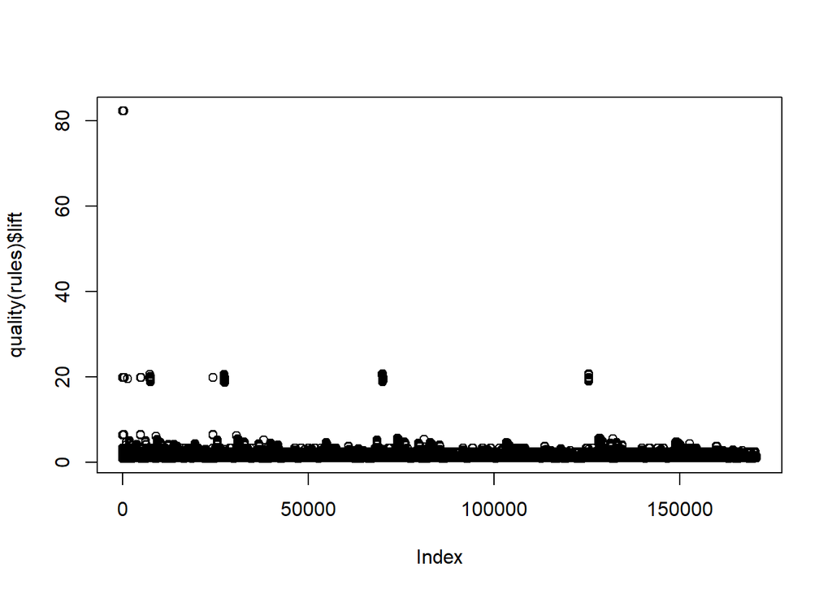

```r
# Generamos gráfico de frecuencias por elevación
plot(quality(rules)$lift,quality(rules)$count)
```

Más técnicas de filtrado de reglas

```r
# Extracción de reglas con una confianza superior a 0.8
subrules = rules[quality(rules)$confidence > 0.8]

subrules
```

```
## set of 131801 rules
```

Filtramos las 30 reglas con mayor elevación y posteriormente las listamos

```r
subrules2 = head(sort(rules, by="lift"), 30);

subrules2
```

```
## set of 30 rules
```

```r
inspect(subrules2)
```

```
##      lhs                                    rhs                        support confidence     lift
## [1]  {education=Doctorate}               => {education-num=(15,20]} 0.01216166  1.0000000 82.22559
## [2]  {education-num=(15,20]}             => {education=Doctorate}   0.01216166  1.0000000 82.22559
## [3]  {education=Doctorate,
##       race=White}                        => {education-num=(15,20]} 0.01076942  1.0000000 82.22559
## [4]  {education-num=(15,20],
##       race=White}                        => {education=Doctorate}   0.01076942  1.0000000 82.22559
## [5]  {fnlwgt=(1e+05,5e+05],
##       marital-status=Married-civ-spouse,
##       race=White,
##       sex=Female,
##       native-country=United-States,
##       income=large}                      => {relationship=Wife}     0.01009377  0.9840319 20.61866
## [6]  {marital-status=Married-civ-spouse,
##       race=White,
##       sex=Female,
##       native-country=United-States,
##       income=large}                      => {relationship=Wife}     0.01238688  0.9837398 20.61254
## [7]  {marital-status=Married-civ-spouse,
##       sex=Female,
##       native-country=United-States,
##       income=large}                      => {relationship=Wife}     0.01359486  0.9822485 20.58129
## [8]  {marital-status=Married-civ-spouse,
##       race=White,
##       sex=Female,
##       income=large}                      => {relationship=Wife}     0.01328774  0.9818457 20.57285
## [9]  {fnlwgt=(1e+05,5e+05],
##       marital-status=Married-civ-spouse,
##       sex=Female,
##       native-country=United-States,
##       income=large}                      => {relationship=Wife}     0.01101511  0.9817518 20.57088
## [10] {fnlwgt=(1e+05,5e+05],
##       marital-status=Married-civ-spouse,
##       race=White,
##       sex=Female,
##       income=large}                      => {relationship=Wife}     0.01081037  0.9814126 20.56377
## [11] {marital-status=Married-civ-spouse,
##       sex=Female,
##       hours-per-week=(30,50],
##       native-country=United-States,
```

[output cut: 68 more lines]

```
## [27] {education-num=(10,15],
##       marital-status=Married-civ-spouse,
##       sex=Female,
##       hours-per-week=(30,50]}            => {relationship=Wife}     0.01296016  0.9620061 20.15714
## [28] {fnlwgt=(1e+05,5e+05],
##       education-num=(10,15],
##       marital-status=Married-civ-spouse,
##       sex=Female,
##       hours-per-week=(30,50]}            => {relationship=Wife}     0.01029851  0.9617591 20.15197
## [29] {education-num=(10,15],
##       marital-status=Married-civ-spouse,
##       sex=Female}                        => {relationship=Wife}     0.01838582  0.9614561 20.14562
## [30] {age=(35,45],
##       marital-status=Married-civ-spouse,
##       sex=Female}                        => {relationship=Wife}     0.01498710  0.9606299 20.12831
```

```r
oneRule = sample(rules, 1);

inspect(oneRule);
```

```
##     lhs                               rhs                                    support confidence    lift
## [1] {fnlwgt=(1e+05,5e+05],
##      occupation=Machine-op-inspct,
##      relationship=Husband,
##      sex=Male,
##      hours-per-week=(30,50]}       => {marital-status=Married-civ-spouse} 0.02153884  0.9990503 2.18042
```

# 5 Función eclat()

Una aproximación distinta puede ser usar la función **R** **eclat()** para identificar los valores más significativos de las distintas características

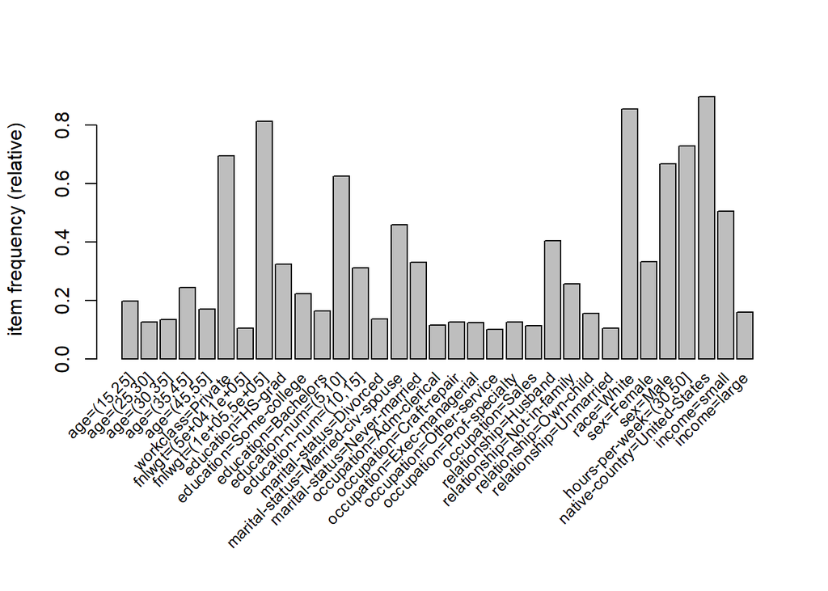

```r
itemFrequencyPlot(Adult, support = 0.1, cex.names=0.8)
```

```r
# Creamos sets o combinaciones de características según su relevancia.
fsets = eclat(Adult, parameter = list(support = 0.05), control = list(verbose=FALSE));

# Seleccionamos los sets con un solo item o característica
singleItems = fsets[size(items(fsets)) == 1];
inspect(singleItems)
```

```
##      items                               support
## [1]  {native-country=United-States}      0.89742435
## [2]  {race=White}                        0.85504279
## [3]  {fnlwgt=(1e+05,5e+05]}              0.81364399
## [4]  {hours-per-week=(30,50]}            0.72798002
## [5]  {workclass=Private}                 0.69419762
## [6]  {sex=Male}                          0.66848204
## [7]  {education-num=(5,10]}              0.62487204
## [8]  {income=small}                      0.50612178
## [9]  {marital-status=Married-civ-spouse} 0.45819172
## [10] {relationship=Husband}              0.40366897
## [11] {sex=Female}                        0.33151796
## [12] {marital-status=Never-married}      0.32998239
## [13] {education=HS-grad}                 0.32316449
## [14] {education-num=(10,15]}             0.31075714
```

[output cut: 31 more lines]

```r
singleSupport = quality(singleItems)$support;

names(singleSupport) = unlist(LIST(items(singleItems), decode = FALSE));

head(singleSupport, n = 5);
```

```
##       136        74        19        94        11
## 0.8974243 0.8550428 0.8136440 0.7279800 0.6941976
```

```r
itemsetList = LIST(items(fsets), decode = FALSE);

# Determinamos la confianza de cada set
allConfidence = quality(fsets)$support / sapply(itemsetList, function(x) max(singleSupport[as.character(x)]));

quality(fsets) = cbind(quality(fsets), allConfidence);

summary(fsets)
```

```
## set of 6270 itemsets
##
## most frequent items:
## native-country=United-States                   race=White
##                         2921                         2803
##         fnlwgt=(1e+05,5e+05]       hours-per-week=(30,50]
##                         2613                         2337
##            workclass=Private                      (Other)
##                         2304                        15412
##
## element (itemset/transaction) length distribution:sizes
##    1    2    3    4    5    6    7    8    9   10
##   45  331 1037 1733 1679  983  363   86   12    1
##
##    Min. 1st Qu.  Median    Mean 3rd Qu.    Max.
##   1.000   4.000   4.000   4.528   5.000  10.000
##
## summary of quality measures:
##     support        allConfidence
##  Min.   :0.05004   Min.   :0.05576
##  1st Qu.:0.05923   1st Qu.:0.07068
##  Median :0.07377   Median :0.08900
##  Mean   :0.09725   Mean   :0.12339
##  3rd Qu.:0.10431   3rd Qu.:0.12994
##  Max.   :0.89742   Max.   :1.00000
##
## includes transaction ID lists: FALSE
##
## mining info:
##   data ntransactions support
##  Adult         48842    0.05
```

# 6 Preguntas

## 6.1 Pregunta 01

Al inicio de la práctica se realiza una tarea de categorización o discretización de las variables continuas del juego de datos AdultUCI.

El paquete **arules** dispone de la función **discretize()** para proceder a realizar tareas de categorización de variables contínuas.

Explica qué métodos de discretización acepta esta variable y aplica cada método en la tabla AdultUCI para categorizar sus variables continuas.

**Atención!** El método “frequency” puede dar el siguiente error “Some breaks are not unique, use fewer breaks for the data”. Es normal, simplemente reducid el númeo de intervalos.

**Respuesta**

Soporta estos metodos, interval, frequency, cluster y fixed

```r
AdultUCI_interval <- AdultUCI
AdultUCI_interval$age <- discretize(AdultUCI_interval$age, method = "interval")
AdultUCI_interval$fnlwgt <- discretize(AdultUCI_interval$fnlwgt, method = "interval")
AdultUCI_interval$`education-num` <- discretize(AdultUCI_interval$`education-num`, method = "interval")
AdultUCI_interval$`capital-gain` <- discretize(AdultUCI_interval$`capital-gain`, method = "interval")
AdultUCI_interval$`capital-loss` <- discretize(AdultUCI_interval$`capital-loss`, method = "interval")
AdultUCI_interval$`hours-per-week` <- discretize(AdultUCI_interval$`hours-per-week`, method = "interval")

AdultUCI_frequency <- AdultUCI
AdultUCI_frequency$age <- discretize(AdultUCI_frequency$age, method = "frequency")
AdultUCI_frequency$fnlwgt <- discretize(AdultUCI_frequency$fnlwgt, method = "frequency")
AdultUCI_frequency$`education-num` <- discretize(AdultUCI_frequency$`education-num`, method = "frequency")
AdultUCI_frequency$`capital-gain` <- discretize(AdultUCI_frequency$`capital-gain`, method = "frequency")
AdultUCI_frequency$`capital-loss` <- discretize(AdultUCI_frequency$`capital-loss`, method = "frequency")
AdultUCI_frequency$`hours-per-week` <- discretize(AdultUCI_frequency$`hours-per-week`, method = "frequency")

AdultUCI_cluster <- AdultUCI
AdultUCI_cluster$age <- discretize(AdultUCI_cluster$age, method = "cluster")
AdultUCI_cluster$fnlwgt <- discretize(AdultUCI_cluster$fnlwgt, method = "cluster")
AdultUCI_cluster$`education-num` <- discretize(AdultUCI_cluster$`education-num`, method = "cluster")
AdultUCI_cluster$`capital-gain` <- discretize(AdultUCI_cluster$`capital-gain`, method = "cluster")
AdultUCI_cluster$`capital-loss` <- discretize(AdultUCI_cluster$`capital-loss`, method = "cluster")
AdultUCI_cluster$`hours-per-week` <- discretize(AdultUCI_cluster$`hours-per-week`, method = "cluster")

AdultUCI_fixed <- AdultUCI
AdultUCI_fixed$age <- discretize(AdultUCI_fixed$age, method = "fixed", categories = c(-Inf,.8,Inf))
AdultUCI_fixed$fnlwgt <- discretize(AdultUCI_fixed$fnlwgt, method = "fixed", categories = c(-Inf,.8,Inf))
AdultUCI_fixed$`education-num` <- discretize(AdultUCI_fixed$`education-num`, method = "fixed", categories = c(-Inf,.8,Inf))
AdultUCI_fixed$`capital-gain` <- discretize(AdultUCI_fixed$`capital-gain`, method = "fixed", categories = c(-Inf,.8,Inf))
AdultUCI_fixed$`capital-loss` <- discretize(AdultUCI_fixed$`capital-loss`, method = "fixed", categories = c(-Inf,.8,Inf))
AdultUCI_fixed$`hours-per-week` <- discretize(AdultUCI_fixed$`hours-per-week`, method = "fixed", categories = c(-Inf,.8,Inf))
```

## 6.2 Pregunta 02

1. Lista las 5 reglas de la variable **rules** con más soporte.
2. Genera un gráfico de frecuencias por soporte.
3. Comenta 2 reglas

**Respuesta**

```r
subrules3 <- head(sort(rules, by="support"), 5)

subrules3_inspect <- inspect(subrules3)
```

```
##     lhs                               rhs
## [1] {}                             => {native-country=United-States}
## [2] {}                             => {race=White}
## [3] {}                             => {fnlwgt=(1e+05,5e+05]}
## [4] {race=White}                   => {native-country=United-States}
## [5] {native-country=United-States} => {race=White}
##     support   confidence lift
## [1] 0.8974243 0.8974243  1.000000
## [2] 0.8550428 0.8550428  1.000000
## [3] 0.8136440 0.8136440  1.000000
## [4] 0.7881127 0.9217231  1.027076
## [5] 0.7881127 0.8781940  1.027076
```

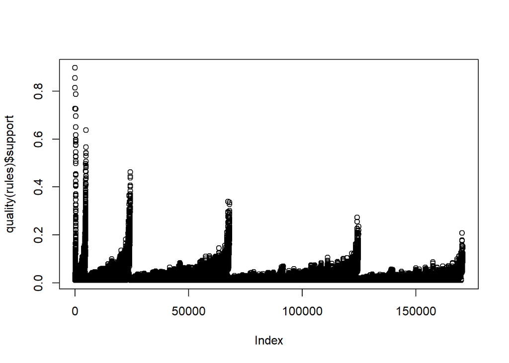

```r
plot(quality(rules)$support,quality(rules)$count)
```

## 6.3 Pregunta 03

1. Investiga el funcionamiento de la función **coverage()** y aplicadlo a la variable **rules**.
2. Lista las 5 reglas con **coverage** más alto.
3. Genera un gráfico de frecuencias por **coverage**.

**Respuesta**

La funcion coverage como dice la documentacion de R se calcula con las variables de support y confidence, representa una medida de cuantas veces puede usarse una regla.

```r
quality(rules) <- cbind(quality(rules), coverage = coverage(rules))

subrules3 <- head(sort(rules, by="coverage"), 5)

inspect(subrules3)
```

```
##     lhs                               rhs                              support confidence      lift  coverage
## [1] {}                             => {hours-per-week=(30,50]}       0.7279800  0.7279800 1.0000000 1.0000000
## [2] {}                             => {fnlwgt=(1e+05,5e+05]}         0.8136440  0.8136440 1.0000000 1.0000000
## [3] {}                             => {race=White}                   0.8550428  0.8550428 1.0000000 1.0000000
## [4] {}                             => {native-country=United-States} 0.8974243  0.8974243 1.0000000 1.0000000
## [5] {native-country=United-States} => {hours-per-week=(30,50]}       0.6502805  0.7246076 0.9953674 0.8974243
```

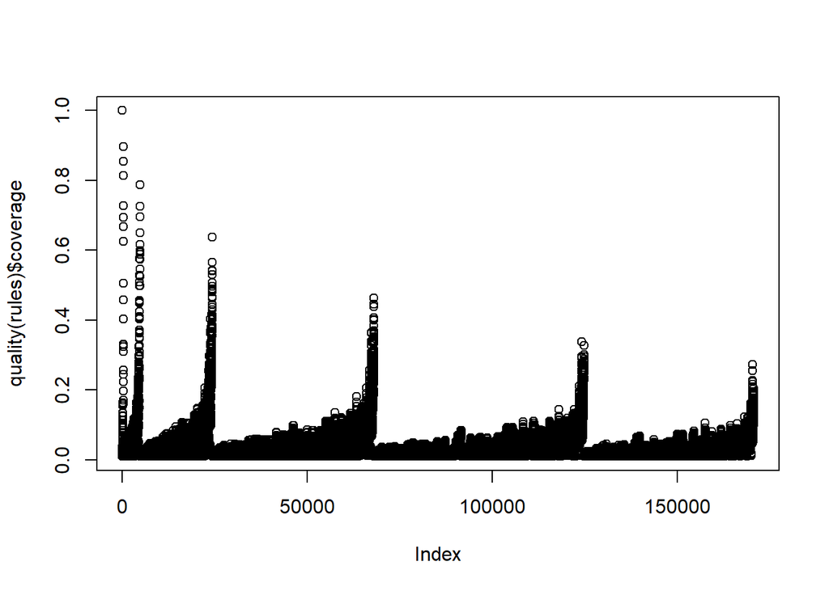

```r
plot(quality(rules)$coverage,quality(rules)$count)
```

## 6.4 Pregunta 04

1. A partir de la función **fsets()** genera sets de 2 items o caraterísticas.
2. A partir del set de 2 items generado, lista las 5 reglas con mayor soporte.

**Respuesta**

```r
fsets = eclat(Adult, parameter = list(support = 0.05), control = list(verbose=FALSE));

# Seleccionamos los sets con un solo item o característica
twoItems = fsets[size(items(fsets)) == 2];
inspect(head(sort(rules, by="support"), 5))
```

```
##     lhs                               rhs
## [1] {}                             => {native-country=United-States}
## [2] {}                             => {race=White}
## [3] {}                             => {fnlwgt=(1e+05,5e+05]}
## [4] {race=White}                   => {native-country=United-States}
## [5] {native-country=United-States} => {race=White}
##     support   confidence lift     coverage
## [1] 0.8974243 0.8974243  1.000000 1.0000000
## [2] 0.8550428 0.8550428  1.000000 1.0000000
## [3] 0.8136440 0.8136440  1.000000 1.0000000
## [4] 0.7881127 0.9217231  1.027076 0.8550428
## [5] 0.7881127 0.8781940  1.027076 0.8974243
```

## 6.5 Pregunta 05

Escoje una de las reglas generadas y comenta los valores de soporte, confianza y elevación que tiene asociados.  
1. ¿Qué significa cada uno de los 3 conceptos?  
2. Aplica cada una de las 3 definiciones a la regla seleccionada

**Respuesta**

Escogemos la regla: {race=White} => {native-country=United-States} 0.7881127 0.9217231 1.027076 0.8550428

El support es la frecuencia en la que la regla aparece en nuestro dataset. La confienza es cuantas veces se ha encontrado que esta regla es cierta. Lift, es la independencia entre estas variables, es decir, 1 son independientes mayor de 1 mas asociacion. Cuanta mayor asociacion, lift, exista en una regla, mejor sera, ya que entendemos que hay esto sera mas facil que ocurra.

Para nuestra regla vemos que el 79% de las veces a aparecido y el 92% de las veces esta regla ha sido true, con un lift de 1.02 significa que estos dos elementos son independientes entre ellos y que no hay mucha asociacion.